# Biost 544 Homework 1

# Question 2

In order to test the hypothesis that the mean observation(survival) time under treatment is no greater than the mean observation(survival) time under control, we used permutation methods and calculated the tail probabilities for each age group. In theory, any permutation of the observations between the two treatments has the same chance to occur as any other permutation. And at the end we will compute the p-value as the proportion of mean survival time from permutation greater than or equal to the observed survival time. For each age group, we will conduct the same hypothesis test, and if p-value is less than or equal to the predetermined level of significance level of 0.05, we can reject the null hypothesis.

For age group 1, we can get one sided tail probability of 0.03, which means a p-value of 0.03 < 0.05, so we can reject the null hypothesis that the effects of treatment and control are the same within this age group. For age group 2, we can get the one-sided tail probability of 0.7, and a p value larger than 0.05 means that we cannot reject the null hypothesis that the effects of the treatment and the control are the same.From our observations from the boxplot, the treatment is actually inferior than the control in this age group. For age group 3, we can get the one-sided tail probability of 0.4, and a p value larger than 0.05 means that we cannot reject the null hypothesis that the effects of the treatment and the control are the same. For age group 4, we can get the one-sided tail probability of 0.06, and a p value larger than 0.05 means that we cannot reject the null hypothesis that the effects of the treatment and the control are the same. For age group 5, we can get the one-sided tail probability of 0.6, and a p value larger than 0.05 mean that we cannot reject the null hypothesis that the effects of the treatment and the control are the same. From our observations from the boxplot, the treatment is actually inferior than the control in this age group. The p-values are summarized in a table to better illustrate the results. From the results, we cannot reach the conclusion that the treatment TFD725+docetaxel is more effective than docetaxel alone for group 2 to 5, since we cannot reject the null that the treatment and control has the same mean observation time across the 4 age groups.

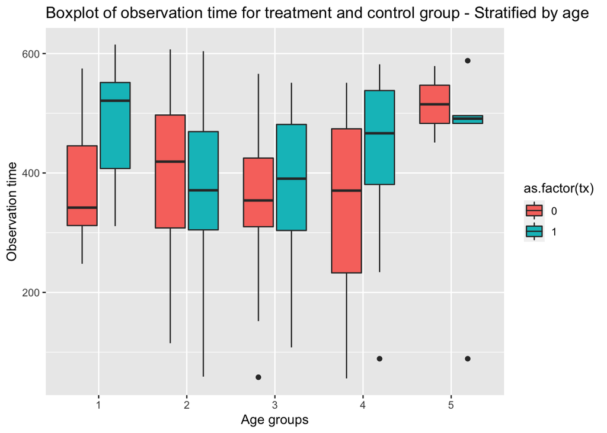

```r
########## creating subgroups
data <- nsclc %>%
  filter(age > 50) %>%
 mutate(subgroup=case_when(
 .$age >= "50" & .$age < "55"   ~ "1",
 .$age >= "55" & .$age < "60"   ~ "2",
 .$age >= "60" & .$age < "65"   ~ "3",
 .$age >= "65" & .$age < "70"   ~ "4",
 .$age >= "70"  ~ "5",))
########## use mean observation time as the effect measurement
ggplot(data = data, aes(x=as.factor(subgroup),y=obstime, fill=as.factor(tx))) + geom_boxplot() +
  xlab("Age groups") +
  ylab("Observation time") +
  ggtitle("Boxplot of observation time for treatment and control group - Stratified by age")
```

```r
######################

simulate.perm.trial <- function(data){

    ## create the permuted data ##
    perm <- sample(1:nrow(data), replace = FALSE) ## generating shuffled ids
    perm.data <- data
    perm.data$tx = data$tx[perm] # mixing everything randomly

    ## calculate the mean/median differences on permuted data
    perm.mean.diff <- with(perm.data,
                           mean(obstime[tx == 1]) - mean(obstime[tx == 0]))
    perm.median.diff <- with(perm.data,
                             median(obstime[tx == 1]) - median(obstime[tx == 0]))
    return( c(perm.mean.diff, perm.median.diff) )
}

mmfunc <- function(a) {
suppressMessages(time.summ <- data %>%
            filter(subgroup == a) %>%
             group_by(tx) %>%
             summarise(avg.time = mean(obstime), median.time = median(obstime)))
# observed difference
diff.summ <- time.summ[2,2:3] - time.summ[1,2:3]
group <- data %>%filter(subgroup == a)
set.seed(1)
permuted.stats <- data.frame(t(replicate(nsim, simulate.perm.trial(group))))
colnames(permuted.stats) <- c("mean.diff","median.diff")

## Calculating tail probabilities
tail.prob.mean <- mean(permuted.stats$mean.diff > diff.summ$avg.time)
tail.prob.medi <- mean(permuted.stats$median.diff > diff.summ$median.time)
tail.prob.mean
}
tail.prob.mean <- as.numeric(lapply(age.set, mmfunc))
pval.tb <- data.frame(Group, tail.prob.mean)
colnames(pval.tb) <- c("Age group", "Tail probability")
formattable(pval.tb)
```

| Age group | Tail probability |
| --- | --- |
| [50,55) | 0.0296 |
| [55,60) | 0.6824 |
| [60,65) | 0.3672 |
| [65,70) | 0.0561 |
| 70+ | 0.5831 |

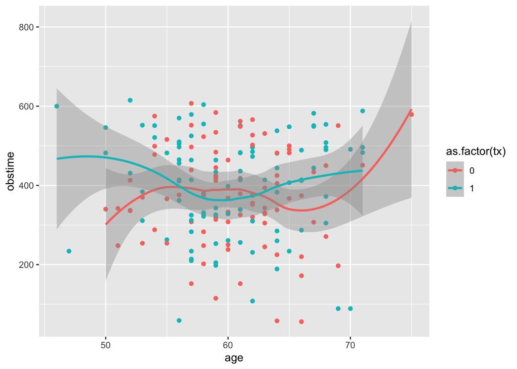

```r
######### making visuals
nsclc %>%
ggplot(aes(x = age, y = obstime, color=as.factor(tx))) +
  geom_point() +
  geom_smooth()
```

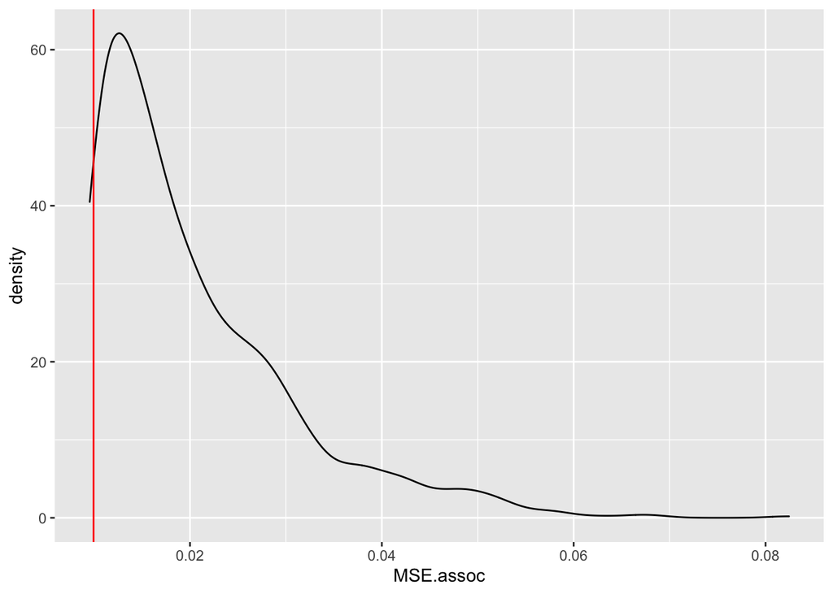

```r
######### calculate p-value for association
fit.null <- lm(obstime ~ 1, data = nsclc) ## no treatment
resids.null <- nsclc$obstime - predict(fit.null)

calc.assoc.meas <- function(data, null.resid) {

 fit.age.perm <- lm(obstime ~ age*as.factor(tx), data=data)
  resids.age.perm <- data$obstime - predict(fit.age.perm)
  MSE.assoc.perm <- 1 - mean(resids.age.perm^2)/mean(null.resid^2) # the r square

  return(MSE.assoc.perm)
}
orig.summary <- calc.assoc.meas(nsclc, resids.null)

simulate.perm.trial <- function(data, null.resid){

  ## create the permuted data ##
  perm <- sample(1:nrow(data), replace = FALSE)
  perm.data <- data
  perm.data$age <- data$age[perm]

  perm.summary <- calc.assoc.meas(data=perm.data, null.resid)

  return( perm.summary )
}
nsim <- 1e3
set.seed(1)
permuted.stats <- data.frame(replicate(nsim, simulate.perm.trial(nsclc, resids.null)))
colnames(permuted.stats) <- ("MSE.assoc")
ggplot(permuted.stats, aes(x=MSE.assoc, y=..density..)) +
  geom_density()+
  geom_vline(xintercept=orig.summary, colour="red")
```

```r
mean(permuted.stats >= orig.summary) # the p-value
```

```
## [1] 0.96
```